# Kansas Primary Election 2020-08-04

Earl F Glynn

2022-04-29

# 1 Setup

## 1.1

## 1.2 Constants

```r
EXCEL_LIMIT <- 2^20
```

```r
params
```

```
$District
[1] "Statewide"

$DistrictName
[1] "Kansas"

$AgeLimit
[1] 105

$ReportTitle
[1] "Kansas Primary Election 2020-08-04"

$ElectionDate
[1] "2020-08-04 UTC"

$ElectionName
[1] "Primary"

$AfterFileDate
[1] "2020-09-04 UTC"

$HistoryIndex
[1] 5
```

## 1.3 Packages

```r
library(tidyverse)
library(lubridate)   # date functions
library(scales)      # comma

library(readxl)
library(writexl)
library(kableExtra)

library(gplots)      # heatmap.2
```

## 1.4 ggplot theme

```r
theme_set(theme_minimal() +

          theme(axis.text             = element_text(size = 10),
                axis.title            = element_text(size = 14),

                legend.position       = "bottom",

                plot.caption          = element_text(hjust = c(0.0,1.0),
                                                     size = 10),
                plot.caption.position = "plot",

                plot.title.position   = "plot",

                strip.background      = element_rect(fill = "aliceblue"),
                strip.text            = element_text(size = 14),

                title                 = element_text(size = 14)))
```

## 1.5 Helper Functions

```r
Show <- function(data, caption="", bigMark="", ...)
{
  data                                                    %>%
  kable("html",
        caption = caption,
        format.args = list(big.mark = bigMark))   %>%
  kable_styling(bootstrap_options = c("striped", "bordered", "condensed"),
                position = "left",
                full_width = FALSE, ...)
}
```

Read `efg`s “standardized” preprocessed version of the voter file from the Kansas Secretary of State.

```r
readVoterFile <- function(Filename)
{
  voterFile <-
  read_csv(Filename, guess_max = EXCEL_LIMIT) %>%
  select(
          ID14,                   # Hash of County, Name, DOB, Gender
          SOSKey,
          Status,
          BirthDate,
          RegisterDate,
          Gender,
          County, City,
          Precinct, Precinct2,
          Party,                 # D, R, L, U, ?
          LastVoteYear,
          TotalVotes,            # Number of ballots in  voting history (max is 10)
          August,                # Number of August ballots cast in even years
          AugPattern,            # Right most "X" is for most recent August Primary
          November,              # Number of November ballots cast in even years
          NovPattern             # Right most "X" is for most recent November General
        )             %>%
  mutate(
          Gender       = recode(Gender,
                                "F"      = "Female",
                                "M"      = "Male",
                                "?"      = "Unknown",
                                .missing = "Unknown"),
          Party        = recode(Party,
                                "?"      = "U",
                                .missing = "U"),
          BirthDate    = as.Date(BirthDate,    "%m/%d/%Y"),
          RegisterDate = as.Date(RegisterDate, "%m/%d/%Y"),
          Age          = round((BirthDate %--% as.Date(ELECTION_DATE)) /
                               years(1)),
          Registered   = (RegisterDate %--% as.Date(ELECTION_DATE)) /
                          years(1),
          RegisteredTooLate = as.integer(
                                          as.Date(RegisterDate, "%m/%d/%Y") >
                                          (as.Date(ELECTION_DATE) - 21)
                                         )
        )

  invisible(voterFile)
}
```

```r
ageDataByGroup <- function(VOTERS, GROUP)
{
  VOTERS                   %>%
  group_by(Age, {{GROUP}}) %>%
  summarize(Registered     = n(),
            Active         = sum(Status == "A",   na.rm = TRUE),
            Voted          = sum(VotedInElection, na.rm = TRUE),

            ActivePercent  = 100 * Active / Registered,
            VotedPercent   = 100 * Voted  / Registered,
            .groups = "drop")   %>%
  ungroup()
}
```

```r
bySummary <- function(VOTERS, GROUP)
{
  VOTERS               %>%
  group_by({{GROUP}})  %>%
  summarize(Registered = n(),
            Active     = sum(Status == "A",   na.rm = TRUE),
            Voted      = sum(VotedInElection, na.rm = TRUE),

            ActivePercent = 100 * Active / Registered,
            VotedPercent  = 100 * Voted  / Registered,
            .groups = "drop")   %>%
  ungroup()
}
```

# 2 Parameters

Use first publicly available voter list after a general election whenever possible.

```r
ELECTION_DATE    <- params$ElectionDate   # Use for age computations
AFTER_FILE_DATE  <- params$AfterFileDate
HISTORY_INDEX    <- params$HistoryIndex
ELECTION_NAME    <- params$ElectionName
```

*Data for Primary Election 2020-08-04 is from file 2020-09-04.*

Registration for Kansas elections closes 21 days before an election. See [Voter Registration Deadlines](https://www.ncsl.org/research/elections-and-campaigns/voter-registration-deadlines.aspx).

Voters registered after that date are excluded from analysis, unless voter history indicates they voted. There’s no practical way to resolve such inconsistent data.

```r
FigureDistrict <- paste(params$DistrictName, params$District)
FigureTitle    <- paste("Kansas", ELECTION_NAME, "Election", ELECTION_DATE)
Source         <- paste("Source:  Kansas Secretary of State, Voter File ",
                        AFTER_FILE_DATE)
Stamp          <- paste("efg", format(time.1, "%Y-%m-%d %H%M"))
```

# 3 Read Kansas Data

```r
afterFilename <- paste0(paste0("E:/Data/Kansas/RawData/",
                               str_sub(ELECTION_DATE, 1, 3), "0s/"),     #####
                        str_sub(AFTER_FILE_DATE, 1, 4), "/",
                        AFTER_FILE_DATE, "/KSCVRID.CSV")
voterList <- readVoterFile(afterFilename)
```

```r
nrow(voterList)
```

```
[1] 1873356
```

## 3.1 Add `VotedInElection` variable

```r
if (ELECTION_NAME == "Primary")
{
  voterList <-
    voterList %>%
    mutate(
            VotedInElection =
              as.integer(substr(AugPattern, HISTORY_INDEX, HISTORY_INDEX) == "X")
          )
}

if (ELECTION_NAME == "General")
{
  voterList <-
    voterList %>%
    mutate(
            VotedInElection =
              as.integer(substr(NovPattern, HISTORY_INDEX, HISTORY_INDEX) == "X")
          )
}
```

## 3.2 Exclude if registered after 3 weeks before election

```r
table(voterList$VotedInElection, voterList$RegisteredTooLate, useNA = "ifany")
```

```
          0       1    <NA>
  0 1236949   22119       2
  1  610495    3790       1
```

```r
registeredTooLate <-
  voterList  %>%
  filter(VotedInElection   == 0,
         RegisteredTooLate == 1)

nrow(registeredTooLate)
```

```
[1] 22119
```

```r
voterList <-
  voterList   %>%
  filter(VotedInElection   == 1  |
         RegisteredTooLate == 0)

nrow(voterList)
```

```
[1] 1851235
```

# 4 Statewide Summary

```r
voterList %>%
  summarize(
             nRecords = n(),
             nID14    = n_distinct(ID14),
             nSOSKey  = n_distinct(SOSKey),
             nVoted   = sum(VotedInElection, na.rm = TRUE),
             nParty   = n_distinct(Party),
             nGender  = n_distinct(Gender),
             nCounty  = n_distinct(County),
             nPrecinct = n_distinct(Precinct),
             minAge   = min(Age, na.rm = TRUE),
             maxAge   = max(Age, na.rm = TRUE)
            )  %>%
  Show(bigMark = ",")
```

| nRecords | nID14 | nSOSKey | nVoted | nParty | nGender | nCounty | nPrecinct | minAge | maxAge |
| --- | --- | --- | --- | --- | --- | --- | --- | --- | --- |
| 1,851,235 | 1,851,149 | 1,851,235 | 614,286 | 4 | 3 | 105 | 3,714 | 18 | 221 |

When `nSOSKey` > `nID14` there are very likely some duplicate voter records that should be deleted.

Number of voters with age > 105 years old (or missing birthdates):

```r
tooOld <-
  voterList  %>%
  filter(Age > params$AgeLimit | is.na(Age))

nrow(tooOld)
```

```
[1] 228
```

These “too old” voters (or those without age) written to file `Too-Old-Voters.xlsx’

```r
if (nrow(tooOld) > 0)
{
  write_xlsx(tooOld, paste0("Too-Old-Voters-", params$DistrictName, ".xlsx"))
}
```

Any too young?

```r
tooYoung <-
  voterList  %>%
  filter(Age < 18)

nrow(tooYoung)
```

```
[1] 0
```

```r
if (nrow(tooYoung) > 0)
{
  write_xlsx(tooYoung, paste0("Too-Young-Voters-", params$DistrictName, ".xlsx"))
}
```

Voter count after removal of “too young”, “too old” and missing age

```r
voterList <-
  voterList  %>%
  filter(Age >= 18,
         Age <= params$AgeLimit,
         !is.na(Age))

nrow(voterList)
```

```
[1] 1851007
```

## 4.1 Counts by Age

Number of age intervals

```r
ageData  <-
  voterList            %>%
  group_by(Age)        %>%
  summarize(Registered = n(),
            Active     = sum(Status == "A",   na.rm = TRUE),
            Voted      = sum(VotedInElection, na.rm = TRUE),

            ActivePercent = 100 * Active / Registered,
            VotedPercent  = 100 * Voted  / Registered,
            .groups = "drop")   %>%
  ungroup()

nrow(ageData)
```

```
[1] 88
```

Total number of Registered, Active, Ballots Cast

```r
countsRegistered <- sum(ageData$Registered, na.rm = TRUE)
countsActive     <- sum(ageData$Active,     na.rm = TRUE)
countsVoted      <- sum(ageData$Voted,      na.rm = TRUE)

c(countsRegistered, countsActive, countsVoted)
```

```
[1] 1851007 1691311  614269
```

## 4.2 Voter Counts: Registered, Active, Voted by Age

```r
countPlotData <-
  ageData                                                       %>%
  select(Age,
         `Registered Voters` = Registered,
         `Active Voters`     = Active,
         `Ballots Cast`      = Voted)                           %>%
  pivot_longer(-Age, names_to = "Group", values_to = "Voters")  %>%
  mutate(Group = factor(Group,  # control order for legend
                        levels = c("Registered Voters",
                                   "Active Voters",
                                   "Ballots Cast")))            %>%
  arrange(Group, Age)
```

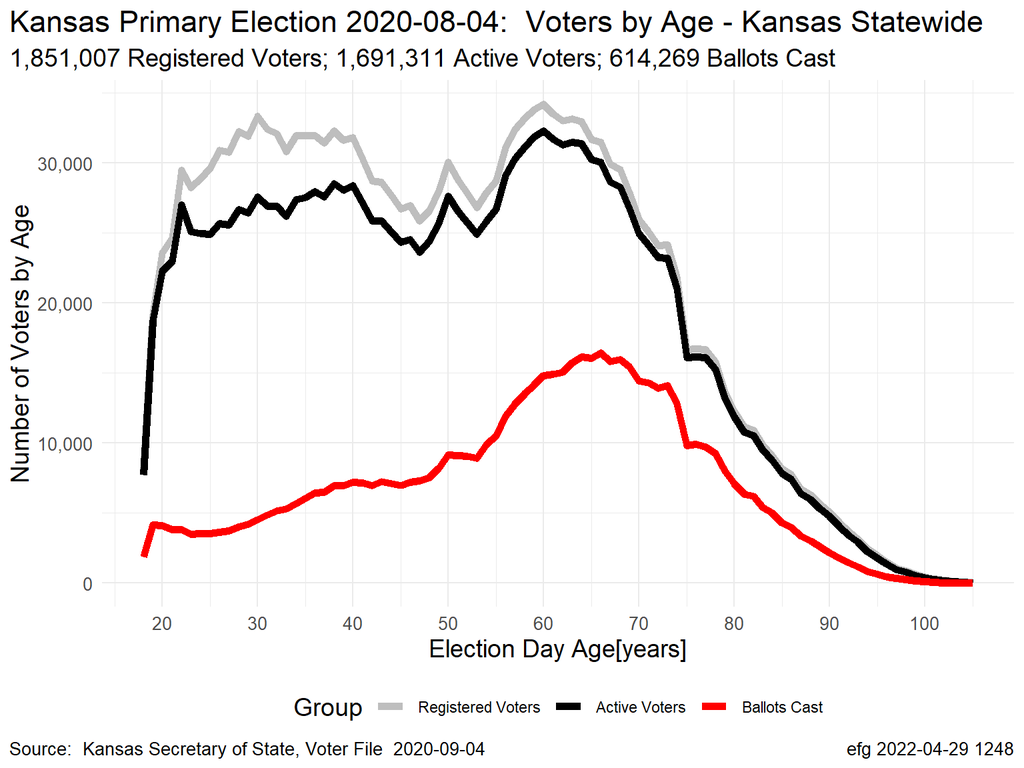

```r
registeredActiveVoted <-
  ggplot(countPlotData, aes(Age, y= Voters, color = Group)) +
  geom_line(size = 2)                                    +
  scale_y_continuous(labels = scales::comma)             +
  scale_x_continuous(breaks = 20 + 0:8 * 10)             +
  scale_color_manual(values = c("grey", "black", "red")) +
  labs(
        title = paste0(FigureTitle, ":  Voters by Age",
                       " - ", FigureDistrict),
        subtitle = paste0(comma(countsRegistered), " Registered Voters; ",
                          comma(countsActive),     " Active Voters; ",
                          comma(countsVoted),      " Ballots Cast "),
        x = "Election Day Age[years]",
        y = "Number of Voters by Age",
        caption = c(Source, Stamp)
      )

print(registeredActiveVoted)
```

```r
write_xlsx(countPlotData %>% spread(Group, Voters),
           "Voter-Counts-by-Age.xlsx")
```

## 4.3 Fraction of Registered Voters by Age: Active, Voted

```r
fractionPlotData <-
  ageData                                                            %>%
  select(Age,
         `Active Voters` = ActivePercent,
         `Ballots Cast`  = VotedPercent)                              %>%
  pivot_longer(-Age, names_to = "Group", values_to = "Percent")       %>%
  mutate(Group = factor(Group,  # control order for legend
                        levels = c("Active Voters", "Ballots Cast"))) %>%
  arrange(Group, Age)
```

```r
overallFractionActive = sum(ageData$Active) / sum(ageData$Registered)
overallFractionVoted  = sum(ageData$Voted)  / sum(ageData$Registered)

c(overallFractionActive, overallFractionVoted)
```

```
[1] 0.9137248 0.3318567
```

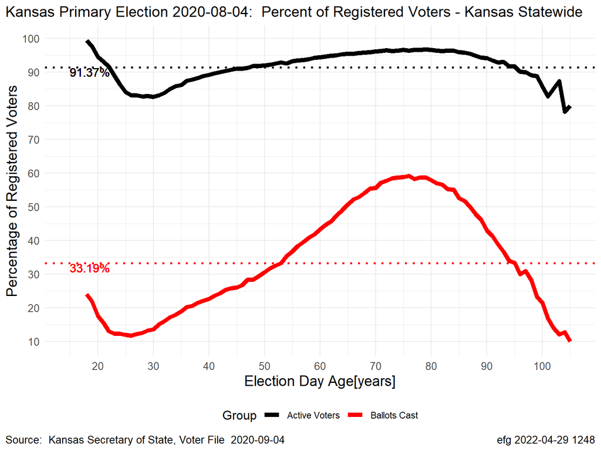

```r
activeVoted <-
  ggplot(fractionPlotData, aes(Age, y= Percent, color = Group))    +
  geom_line(size = 2)                                    +

  geom_hline(yintercept = 100 *overallFractionActive,
             color = "black",
             linetype = "dotted", size = 1)              +
  geom_text(aes(x = 15,
                y = 100 * overallFractionActive,
                label = paste0(round(100 * overallFractionActive, 2), "%")),
                color = "black", hjust = 0, vjust = 1, size = 4)   +

  geom_hline(yintercept = 100 *overallFractionVoted,
             color = "red",
             linetype = "dotted", size = 1)                        +
  geom_text(aes(x = 15,
                y = 100 * overallFractionVoted,
                label = paste0(round(100 * overallFractionVoted, 2), "%")),
                color = "red", hjust = 0, vjust = 1, size = 4)     +

  scale_y_continuous(breaks =      0:10 * 10)            +
  scale_x_continuous(breaks = 20 + 0: 8 * 10)            +
  scale_color_manual(values = c("black", "red"))         +
  labs(
        title = paste0(FigureTitle, ":  Percent of Registered Voters",
                       " - ", FigureDistrict),
        x = "Election Day Age[years]",
        y = "Percentage of Registered Voters",
        caption = c(Source, Stamp)
      )                                                  +
  theme(title = element_text(size = 12))

print(activeVoted)
```

```r
write_xlsx(fractionPlotData %>% spread(Group, Percent),
           "Voter-Percentages-by-Age.xlsx")
```

## 4.4 Normalized Fraction

The normalization is formed by the ratio of turnout by age to the overall turnout for all ages (the dotted line in the diagram above).

What is the intuition for this normalization?

- Normalized fraction < 1 shows ages that “underperformed”.
- Normalized fraction > 1 shows ages that “outperformed”.
- Normalized fraction can be compared across different districts, like state and county.

```r
normalized <-
  ageData    %>%
  mutate(ActiveNormalized = (ActivePercent/100) / overallFractionActive,
         VotedNormalized  = (VotedPercent/100)  / overallFractionVoted)
```

```r
normalizedPlotData <-
  normalized                                                          %>%
  select(Age,
         `Active Voters` = ActiveNormalized,
         `Ballots Cast`  = VotedNormalized)                           %>%
  pivot_longer(-Age, names_to = "Group", values_to = "Ratio")         %>%
  mutate(Group = factor(Group,  # control order for legend
                        levels = c("Active Voters", "Ballots Cast"))) %>%
  arrange(Group, Age)
```

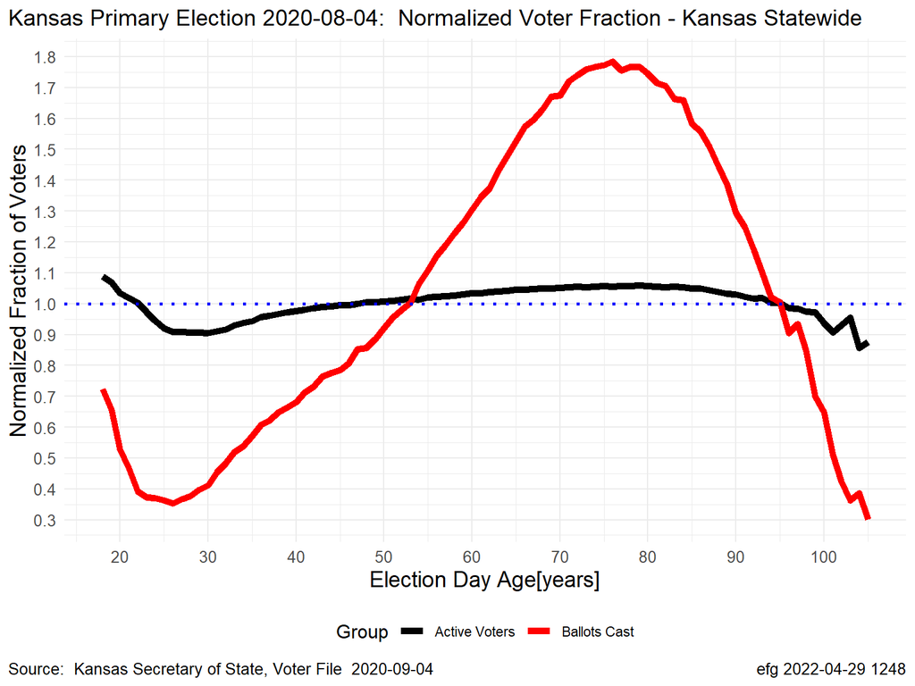

```r
normalizedVoted <-
  ggplot(normalizedPlotData, aes(Age, y= Ratio, color = Group))  +
  geom_line(size = 2)                                            +
  geom_hline(yintercept = 1.0, color = "blue",
             linetype = "dotted", size = 1)                      +
  scale_x_continuous(breaks = 20 + 0: 8 * 10)                    +
  scale_y_continuous(breaks = 0.01 * 0:24 * 10)                  +
  scale_color_manual(values = c("black", "red"))                 +
  labs(
        title = paste0(FigureTitle, ":  Normalized Voter Fraction",
                       " - ", FigureDistrict),
        x = "Election Day Age[years]",
        y = "Normalized Fraction of Voters",
        caption = c(Source, Stamp)
      )                                                          +
  theme(title = element_text(size = 12))

print(normalizedVoted)
```

```r
write_xlsx(normalizedPlotData %>% spread(Group, Ratio),
           "Voter-Normalized-by-Age.xlsx")
```

# 5 By Party

```r
ageDataByParty <- ageDataByGroup(voterList, Party)
nrow(ageDataByParty)
```

```
[1] 344
```

```r
byParty <- bySummary(voterList, Party)
byParty %>%  Show(bigMark = ",")
```

| Party | Registered | Active | Voted | ActivePercent | VotedPercent |
| --- | --- | --- | --- | --- | --- |
| D | 495,912 | 455,129 | 198,836 | 91.77616 | 40.0950169 |
| L | 18,614 | 16,080 | 358 | 86.38659 | 1.9232836 |
| R | 838,150 | 788,757 | 410,739 | 94.10690 | 49.0054286 |
| U | 498,331 | 431,345 | 4,336 | 86.55793 | 0.8701044 |

```r
countPlotDataByParty <-
  ageDataByParty                                                          %>%
  select(Age, Party,
         `Registered Voters` = Registered,
         `Active Voters`     = Active,
         `Ballots Cast`      = Voted)                                     %>%
  pivot_longer(c(-Age,-Party), names_to = "Group", values_to = "Voters")  %>%
  mutate(Group = factor(Group,  # control order for legend
                        levels = c("Registered Voters",
                                   "Active Voters",
                                   "Ballots Cast")))                      %>%
  arrange(Group, Age, Party)

nrow(countPlotDataByParty)
```

```
[1] 1032
```

## 5.1 Voter Registration Counts

```r
partyCounts <- table(voterList$Party)
partyCounts
```

```
     D      L      R      U
495912  18614 838150 498331
```

```r
partyLabel <- c("D" = paste("Democratic",   comma(partyCounts["D"])),
                "L" = paste("Libertarian",  comma(partyCounts["L"])),
                "R" = paste("Republican",   comma(partyCounts["R"])),
                "U" = paste("Unaffiliated", comma(partyCounts["U"])))
```

```r
if (length(partyCounts) == 5)   # 2010 and earlier
{
  partyLabel = c(partyLabel[1],
                 "F" = paste("Reform",  comma(partyCounts["F"])),
                 partyLabel[2:4])
}
```

```r
registeredActiveVotedByParty <-
  ggplot(countPlotDataByParty,
         aes(x = Age, y= Voters, color = Group))         +
  geom_line(size = 2)                                    +
  scale_y_continuous(labels = scales::comma)             +
  scale_x_continuous(breaks = 20 + 0:8 * 10)             +
  scale_color_manual(values = c("grey", "black", "red")) +
  labs(
        title = paste0(FigureTitle, ":  Voters by Party and Age",
                       " - ", FigureDistrict),
        x = "Election Day Age[years]",
        y = "Number of Voters by Age",
        caption = c(Source, Stamp)
      )                                                  +
  theme(panel.grid.minor.x = element_blank())            +
  facet_wrap(~Party,
             ncol = length(partyLabel),
             labeller = labeller(Party = partyLabel))    +
  geom_text(data = byParty,
            aes(x = 15,
                y = Inf,
                label = paste0(comma(Active), " Active Voters\n",
                               comma(Voted),  " Ballots Cast")),
            color = "black", hjust = 0, vjust = 1, size = 4)
```

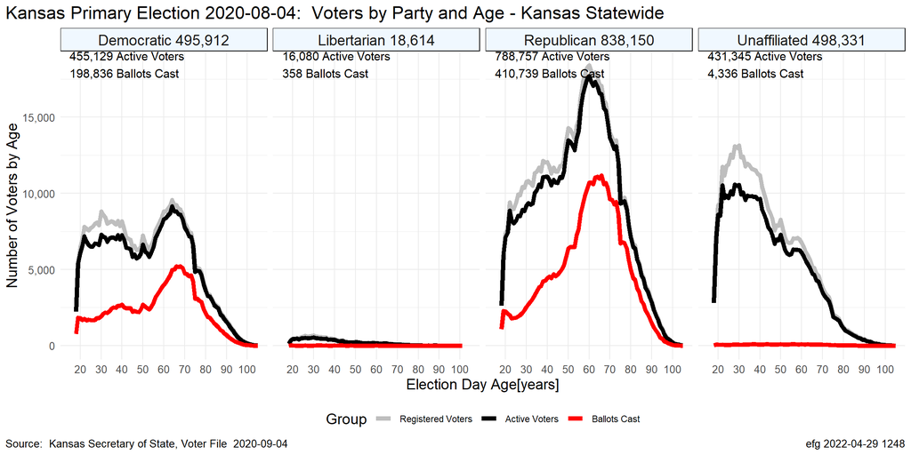

```r
print(registeredActiveVotedByParty)
```

## 5.2 Fraction of Voters

```r
partyLabelFraction <-
  c("D" = paste0("Democratic ",
                 round(100 * partyCounts["D"] / sum(partyCounts), 2), "%"),

    "L" = paste0("Libertarian ",
                 round(100 * partyCounts["L"] / sum(partyCounts), 2), "%"),

    "R" = paste0("Republican ",
                 round(100 * partyCounts["R"] / sum(partyCounts), 2), "%"),

    "U" = paste0("Unaffiliated ",
                 round(100 * partyCounts["U"] / sum(partyCounts), 2), "%"))
```

```r
if (length(partyCounts) == 5)   # 2010 and earlier
{
  partyLabelFraction = c(partyLabelFraction[1],
                         "F" = paste0("Reform ",
                                      round(100 * partyCounts["F"] / sum(partyCounts), 2), "%"),
                         partyLabelFraction[2:4])
}
```

```r
fractionByPartyAge <-
  ageDataByParty                                                      %>%
  select(Age, Party,
         `Active Voters` = ActivePercent,
         `Ballots Cast`  = VotedPercent)                              %>%
  pivot_longer(c(-Age, -Party), names_to = "Group", values_to = "Percent")  %>%
  mutate(Group = factor(Group,  # control order for legend
                        levels = c("Active Voters", "Ballots Cast"))) %>%
  arrange(Group, Age, Party)
```

```r
fractionByParty <-
  ageDataByParty
```

```r
activeVotedByParty <-
  ggplot(fractionByPartyAge, aes(Age, y= Percent, color = Group)) +
  geom_line(size = 2)                                    +
  scale_y_continuous(breaks =      0:10 * 10)            +
  scale_x_continuous(breaks = 20 + 0: 8 * 10)            +
  scale_color_manual(values = c("black", "red")) +
  labs(
        title = paste0(FigureTitle, ":  Percentage of Registered Voters by Party and Age",
                       " - ", FigureDistrict),
        x = "Election Day Age[years]",
        y = "Percentage of Registered Voters",
        caption = c(Source, Stamp)
      )                                                  +
  theme(panel.grid.minor.x = element_blank(),
        panel.grid.minor.y = element_blank())            +

  facet_grid(col = vars(Party),
             labeller = labeller(Party = partyLabelFraction),
             scales = "free_x")                          +

  geom_hline(data = byParty,
             aes(yintercept = ActivePercent),
             color = "black",
             linetype = "dotted", size = 1)              +
  geom_text(data = byParty,
            aes(x = 15,
                y = ActivePercent,
                label = paste0(round(ActivePercent, 1), "%")),
            color = "black", hjust = 0, vjust = 1, size = 4)   +

  geom_hline(data = byParty,
             aes(yintercept = VotedPercent),
             color = "red",
             linetype = "dotted", size = 1)               +
  geom_text(data = byParty,
            aes(x = 15,
                y = VotedPercent,
                label = paste0(round(VotedPercent, 1), "%")),
            color = "red", hjust = 0, vjust = 1, size = 4)
```

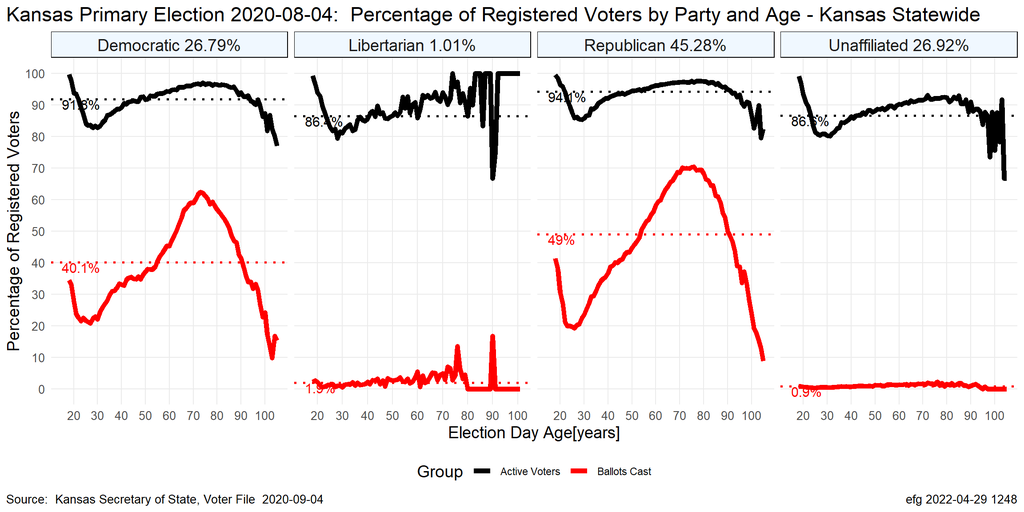

```r
print(activeVotedByParty)
```

# 6 By Gender

```r
ageDataByGender <- ageDataByGroup(voterList, Gender)
nrow(ageDataByGender)
```

```
[1] 253
```

```r
byGender <- bySummary(voterList, Gender)
byGender %>% Show()
```

| Gender | Registered | Active | Voted | ActivePercent | VotedPercent |
| --- | --- | --- | --- | --- | --- |
| Female | 968697 | 886644 | 332662 | 91.52955 | 34.34118 |
| Male | 878029 | 800614 | 280985 | 91.18309 | 32.00179 |
| Unknown | 4281 | 4053 | 622 | 94.67414 | 14.52932 |

```r
countPlotDataByGender <-
  ageDataByGender                             %>%
  select(Age, Gender,
         `Registered Voters` = Registered,
         `Active Voters`     = Active,
         `Ballots Cast`      = Voted)         %>%
  pivot_longer(c(-Age,-Gender), names_to = "Group", values_to = "Voters")  %>%
  mutate(Group = factor(Group,  # control order for legend
                        levels = c("Registered Voters",
                                   "Active Voters",
                                   "Ballots Cast"))) %>%
  arrange(Group, Age, Gender)

nrow(countPlotDataByGender)
```

```
[1] 759
```

## 6.1 Voter Registration Counts

```r
genderCounts <- table(voterList$Gender)
genderCounts
```

```
 Female    Male Unknown
 968697  878029    4281
```

```r
genderLabel <- c("Female"  = paste("Female",  comma(genderCounts["Female"])),
                 "Male"    = paste("Male",    comma(genderCounts["Male"])),
                 "Unknown" = paste("Unknown", comma(genderCounts["Unknown"])))
```

```r
registeredActiveVotedByGender <-
  ggplot(countPlotDataByGender,
         aes(x = Age, y= Voters, color = Group))         +
  geom_line(size = 2)                                    +
  scale_y_continuous(labels = scales::comma)             +
  scale_x_continuous(breaks = 20 + 0:8 * 10)             +
  scale_color_manual(values = c("grey", "black", "red")) +
  labs(
        title = paste0(FigureTitle, ":  By Gender and Age",
                       " - ", FigureDistrict),
        x = "Election Day Age[years]",
        y = "Number of Voters by Age",
        caption = c(Source, Stamp)
      )                                                  +
  theme(panel.grid.minor.x = element_blank())            +
  facet_wrap(~Gender,
             ncol = length(genderLabel),
             labeller = labeller(Gender = genderLabel))    +
  geom_text(data = byGender,
            aes(x = 15,
                y = Inf,
                label = paste0(comma(Active), " active voters\n",
                               comma(Voted),  " ballots cast")),
            color = "black", hjust = 0, vjust = 1, size = 4)
```

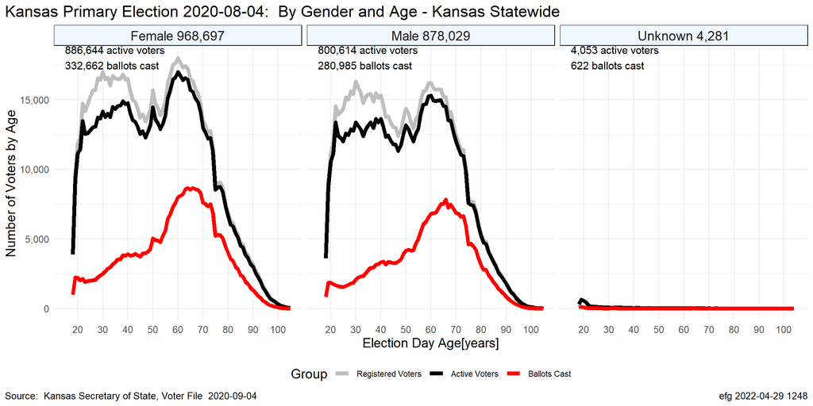

```r
print(registeredActiveVotedByGender)
```

## 6.2 Fraction of Voters

```r
genderLabelFraction <-
  c("Female" = paste0("Female ",
                 round(100 * genderCounts["Female"] / sum(genderCounts), 2), "%"),

    "Male" = paste0("Male ",
                 round(100 * genderCounts["Male"]    / sum(genderCounts), 2), "%"),

    "Unknown" = paste0("Unknown ",
                 round(100 * genderCounts["Unknown"] / sum(genderCounts), 2), "%"))
```

```r
fractionByGenderAge <-
  ageDataByGender                                                     %>%
  select(Age, Gender,
         `Active Voters` = ActivePercent,
         `Ballots Cast`  = VotedPercent)                              %>%
  pivot_longer(c(-Age, -Gender), names_to = "Group", values_to = "Percent")  %>%
  mutate(Group = factor(Group,  # control order for legend
                        levels = c("Active Voters", "Ballots Cast"))) %>%
  arrange(Group, Age, Gender)
```

```r
fractionByGender <-
  ageDataByGender
```

```r
activeVotedByGender <-
  ggplot(fractionByGenderAge, aes(Age, y= Percent, color = Group)) +
  geom_line(size = 2)                                    +
  scale_y_continuous(breaks =      0:10 * 10)            +
  scale_x_continuous(breaks = 20 + 0: 8 * 10)            +
  scale_color_manual(values = c("black", "red")) +
  labs(
        title = paste0(FigureTitle, ":  Percentage By Gender and Age",
                       " - ", FigureDistrict),
        x = "Election Day Age[years]",
        y = "Percentage of Registered Voters",
        caption = c(Source, Stamp)
      )                                                  +
  theme(panel.grid.minor.x = element_blank(),
        panel.grid.minor.y = element_blank())            +

  facet_grid(col = vars(Gender),
             labeller = labeller(Gender = genderLabelFraction),
             scales = "free_x")                          +

  geom_hline(data = byGender,
             aes(yintercept = ActivePercent),
             color = "black",
             linetype = "dotted", size = 1)              +
  geom_text(data = byGender,
            aes(x = 15,
                y = ActivePercent,
                label = paste0(round(ActivePercent, 1), "%")),
            color = "black", hjust = 0, vjust = 1, size = 4)   +

  geom_hline(data = byGender,
             aes(yintercept = VotedPercent),
             color = "red",
             linetype = "dotted", size = 1)               +
  geom_text(data = byGender,
            aes(x = 15,
                y = VotedPercent,
                label = paste0(round(VotedPercent, 1), "%")),
            color = "red", hjust = 0, vjust = 1, size = 4)
```

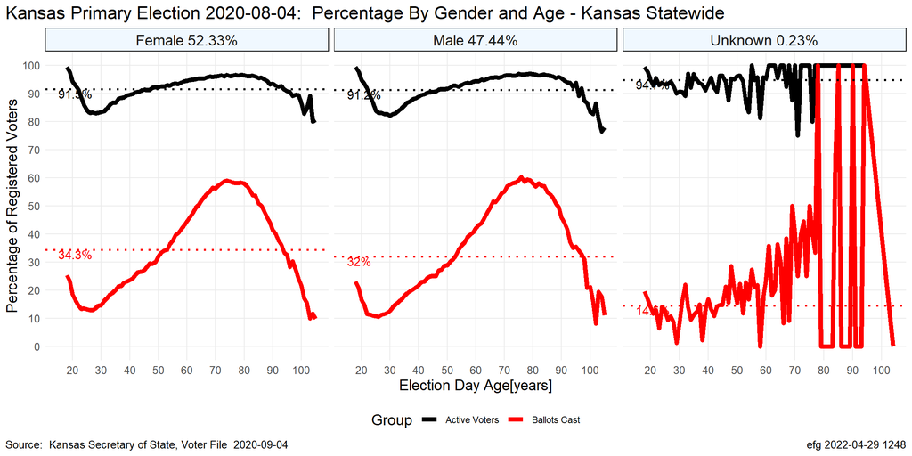

```r
print(activeVotedByGender)
```

# 7 By County

```r
ageDataByCounty <- ageDataByGroup(voterList, County)
nrow(ageDataByCounty)
```

```
[1] 8879
```

```r
byCounty <-
  bySummary(voterList, County)  %>%
  rename(OverallActivePercent = ActivePercent,
         OverallVotedPercent  = VotedPercent)

byCounty                %>%
  arrange(-Registered)  %>%
  Show(bigMark = ",")   %>%
  scroll_box(height = "300px")
```

| County | Registered | Active | Voted | OverallActivePercent | OverallVotedPercent |
| --- | --- | --- | --- | --- | --- |
| Johnson | 431,850 | 385,320 | 149,590 | 89.22543 | 34.6393424 |
| Sedgwick | 304,768 | 288,322 | 90,818 | 94.60376 | 29.7990603 |
| Shawnee | 111,876 | 102,365 | 39,163 | 91.49862 | 35.0057206 |
| Wyandotte | 86,792 | 77,575 | 23,800 | 89.38036 | 27.4218822 |
| Douglas | 78,487 | 66,148 | 29,040 | 84.27893 | 36.9997579 |
| Leavenworth | 47,449 | 44,955 | 16,058 | 94.74383 | 33.8426521 |
| Butler | 42,828 | 39,446 | 15,106 | 92.10330 | 35.2713178 |
| Reno | 39,730 | 36,293 | 14,757 | 91.34911 | 37.1432167 |
| Saline | 36,840 | 32,533 | 11,856 | 88.30890 | 32.1824104 |
| Riley | 35,394 | 30,488 | 10,827 | 86.13889 | 30.5899305 |
| Crawford | 24,601 | 24,179 | 1 | 98.28462 | 0.0040649 |
| Miami | 23,651 | 22,540 | 7,496 | 95.30252 | 31.6942201 |
| Harvey | 22,786 | 20,836 | 8,683 | 91.44211 | 38.1067322 |
| Finney | 20,169 | 17,210 | 4,892 | 85.32897 | 24.2550449 |
| Lyon | 19,661 | 17,518 | 6,190 | 89.10025 | 31.4836478 |
| Montgomery | 19,618 | 17,883 | 6,825 | 91.15608 | 34.7894790 |
| Cowley | 19,570 | 17,792 | 6,540 | 90.91467 | 33.4184977 |
| Franklin | 18,438 | 16,349 | 5,698 | 88.67014 | 30.9035687 |
| Ellis | 18,084 | 16,891 | 6,822 | 93.40301 | 37.7239549 |
| McPherson | 17,226 | 16,525 | 6,975 | 95.93057 | 40.4911181 |
| Sumner | 17,045 | 15,020 | 4,917 | 88.11968 | 28.8471693 |
| Pottawatomie | 15,956 | 14,418 | 6,805 | 90.36099 | 42.6485335 |
| Geary | 15,870 | 14,461 | 3,038 | 91.12161 | 19.1430372 |
| Barton | 15,862 | 14,930 | 6,435 | 94.12432 | 40.5686546 |
| Ford | 14,265 | 13,781 | 3,791 | 96.60708 | 26.5755345 |
| Cherokee | 13,895 | 13,147 | 3,414 | 94.61677 | 24.5699892 |
| Labette | 13,641 | 11,806 | 3,672 | 86.54791 | 26.9188476 |
| Dickinson | 13,008 | 12,219 | 5,063 | 93.93450 | 38.9222017 |
| Jefferson | 12,186 | 11,867 | 4,189 | 97.38224 | 34.3755129 |
| Atchison | 11,625 | 9,512 | 3,773 | 81.82366 | 32.4559140 |

[output cut: 75 more lines]

## 7.1 County Size

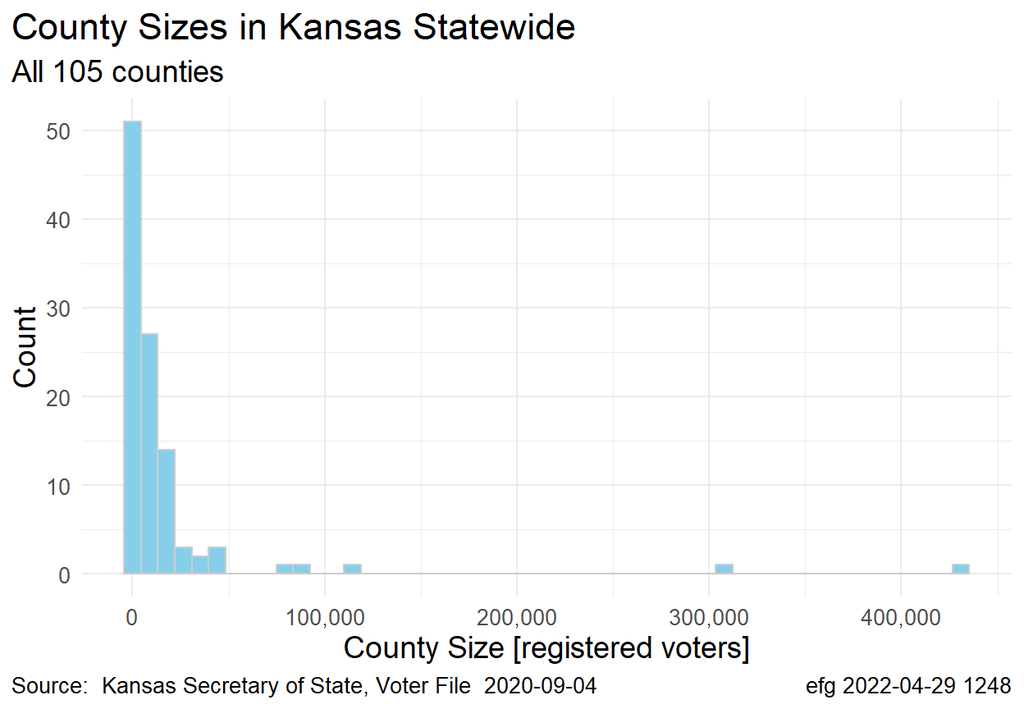

```r
options(scipen = 999)
ggplot(byCounty, aes(x = Registered))                           +
  geom_histogram(fill = "skyblue", color = "grey80", bins = 50) +
  scale_x_continuous(labels = scales::comma)                    +
  labs(title = paste("County Sizes in", FigureDistrict),
       subtitle = paste("All", nrow(byCounty), "counties"),
       x = "County Size [registered voters]",
       y = "Count",
       caption=c(Source, Stamp))
```

For now, let’s only look at voter turnout.

```r
normalizedAgeDataByCounty <-
  byCounty                                     %>%
  select(County, OverallVotedPercent)          %>%
  inner_join(ageDataByCounty,
             by = "County")                    %>%
  mutate(NormalizedFractionVoted = VotedPercent / OverallVotedPercent)  %>%
  select(County, Age, NormalizedFractionVoted) %>%
  arrange(County, Age)

dim(normalizedAgeDataByCounty)
```

```
[1] 8879    3
```

## 7.2 Voter Registration Counts

```r
countyCounts <- table(voterList$County)
```

```r
sum(countyCounts)
```

```
[1] 1851007
```

## 7.3 Scatterplot of State Overall with All Counties

```r
stateNormalized <-
  normalizedPlotData                       %>%
  rename(NormalizedFractionVoted = Ratio)  %>%
  filter(Group == "Ballots Cast")          %>%
  select(-Group)                           %>%
  mutate(County = "Kansas")      %>%
  relocate(County, .before = Age)

dim(stateNormalized)
```

```
[1] 88  3
```

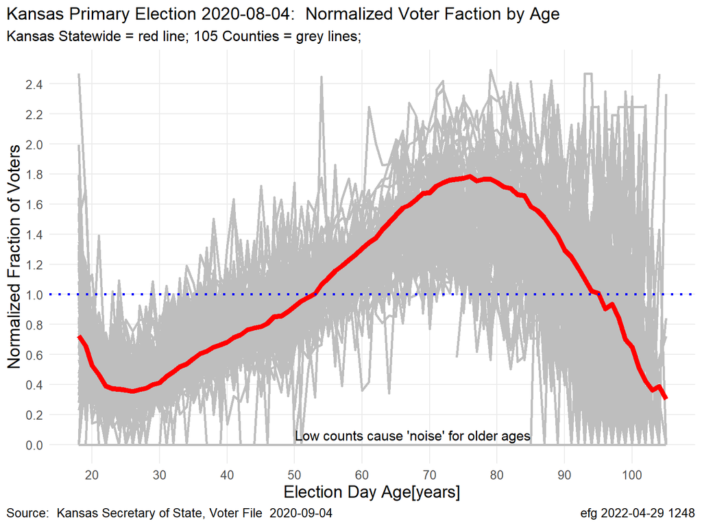

```r
normalizedVoted <-
  ggplot()                                      +

  geom_line(data = normalizedAgeDataByCounty,
            aes(x = Age, y= NormalizedFractionVoted,
                group = County),
            color = "grey", size = 1)           +

  geom_line(data = stateNormalized,
            aes(x = Age, y= NormalizedFractionVoted),
            color = "red", size = 2)            +

  geom_hline(yintercept = 1.0, color = "blue",
             linetype = "dotted", size = 1)     +

  geom_text(aes(x = 85,
                y = 0.1,
                label = "Low counts cause 'noise' for older ages"),
            color = "black", hjust = 1, vjust = 1, size = 4)   +

  scale_x_continuous(breaks = 2:10 * 10)        +
  scale_y_continuous(breaks = 0:12 *  0.2,
                     limits = c(0, 2.5) )       +

  labs(
        title = paste0(FigureTitle, ":  Normalized Voter Faction by Age"),
        subtitle = paste0(FigureDistrict, " = red line; ",
                          length(countyCounts), " Counties = grey lines;"),
        x = "Election Day Age[years]",
        y = "Normalized Fraction of Voters",
        caption = c(Source, Stamp)
      )                                      +
  theme(
         panel.grid.minor.x = element_blank(),
         panel.grid.minor.y = element_blank(),
         title = element_text(size = 12)
       )

print(normalizedVoted)
```

## 7.4 Heatmap

Create matrix

```r
Kansas <-
  bind_rows(stateNormalized,
            normalizedAgeDataByCounty)  %>%
  pivot_wider(names_from = Age,
              values_from = NormalizedFractionVoted,
              values_fill = list(NormalizedFractionVoted = 0))  %>%
  mutate(across(everything(), ~replace_na(.x, 0)))   # kludge fix (e.g., Primary 2006)
```

```r
comparisonMatrix <- as.matrix(Kansas %>% select(-County))
dim(comparisonMatrix)
```

```
[1] 106  88
```

```r
dimnames(comparisonMatrix) <- list(
                                    Kansas$County,
                                    colnames(Kansas[-1]) %>% as.numeric()
                                   )
```

```r
comparisonMatrix[1:5, 1:5]
```

```
                18        19        20        21        22
Kansas   0.7243925 0.6567415 0.5287744 0.4673821 0.3908956
Allen    1.0870868 0.4489184 0.5378932 0.2696091 0.4277305
Anderson 1.0605580 0.9942732 0.6034210 0.4242232 0.6791930
Atchison 0.5777067 0.5572207 0.5088059 0.2706374 0.3555118
Barber   0.7747197 1.0091743 0.4980341 0.6972477 0.3936076
```

```r
ratioStats <- fivenum(comparisonMatrix)

ratioStats
```

```
[1]  0.0000000  0.4805278  0.9255005  1.3112822 56.6041667
```

```r
colorBreaks <-
  c(
    seq(0.0, 1.0, length.out = 9),
    seq(1.0, 2.0, length.out = 9)[-1]
  )

colorBreaks
```

```
 [1] 0.000 0.125 0.250 0.375 0.500 0.625 0.750 0.875 1.000 1.125 1.250 1.375
[13] 1.500 1.625 1.750 1.875 2.000
```

Attempt to “balance” palette above and below 1.

```r
colorPalette <-
  c(colorRampPalette(c("red",   "white"))(9)[1:8],    # skip last
    "#FFFFFF",                                        # color for ratio of 1
    colorRampPalette(c("white", "skyblue"))(8)[2:8])  # skip first

colorPalette
```

```
 [1] "#FF0000" "#FF1F1F" "#FF3F3F" "#FF5F5F" "#FF7F7F" "#FF9F9F" "#FFBFBF"
 [8] "#FFDFDF" "#FFFFFF" "#EDF8FC" "#DCF1F9" "#CBEAF6" "#BAE3F3" "#A9DCF0"
[15] "#98D5ED" "#87CEEB"
```

```r
# layout matrix 1 = heatmap, 2 = row dendrogrm, 3 = column dendrogram, 4 = key
lmat <- rbind( c(0, 3, 3),  # layout matrix
               c(2, 1, 1),
               c(0, 0, 4))

lwid <- c(3, 4, 4)          # entry for each column in layout matrix

# relative height of the rows. must have length = nrow(lmat)
lhei <- c(0.25, 4, 0.20)    # entry for each row in layout matrix
```

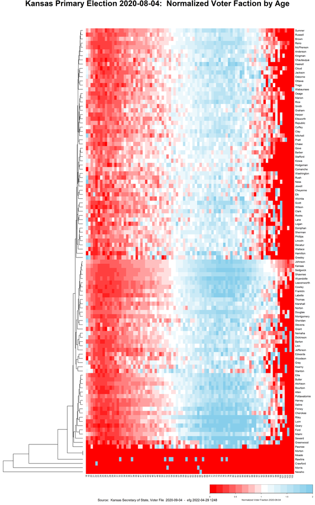

```r
oldPar <- par(mar = c(5, 0, 2, 0))

heatmap.2(
           comparisonMatrix,
           scale      = "none",
           dendrogram = "row",
           Colv       = NA,         # suppress reordering of columns

           trace  = "none",         # turns off trace lines inside the heat map
           col    = colorPalette,
           breaks = colorBreaks,

           margins = c(4, 10),      # column and row names

           cexRow = 1.5,
           cexCol = 1.25,

           key.title = NA,           # suppress title
           key.xlab  = paste0("Normalized Voter Fraction ", ELECTION_DATE),
           keysize   = 3,
           density.info = "none",    # turns off density plot inside color legend

           lmat = lmat, lwid = lwid, lhei = lhei
         )
title(main = paste0(FigureTitle,
                    ":  Normalized Voter Faction by Age"),
      cex.main = 3,
      sub = paste(Source, " - ", Stamp),
      cex.sub  = 1.25)

par(oldPar)
```

# 8 Fini

## 8.1

Processing time: 54.5 secs

2022-04-29 1249